# Lab 4

Eric Miao, Sabrina Peng, Fernando Vazquez

CS7324, Fall 2020

```python
import numpy as np
import pandas as pd
import matplotlib
import matplotlib.pyplot as plt
```

## 1. Load, Split, Balance

```python
# read data and display all columns

df = pd.read_csv('acs2017_census_tract_data.csv')
df.columns
```

```
Index(['TractId', 'State', 'County', 'TotalPop', 'Men', 'Women', 'Hispanic',
       'White', 'Black', 'Native', 'Asian', 'Pacific', 'VotingAgeCitizen',
       'Income', 'IncomeErr', 'IncomePerCap', 'IncomePerCapErr', 'Poverty',
       'ChildPoverty', 'Professional', 'Service', 'Office', 'Construction',
       'Production', 'Drive', 'Carpool', 'Transit', 'Walk', 'OtherTransp',
       'WorkAtHome', 'MeanCommute', 'Employed', 'PrivateWork', 'PublicWork',
       'SelfEmployed', 'FamilyWork', 'Unemployment'],
      dtype='object')
```

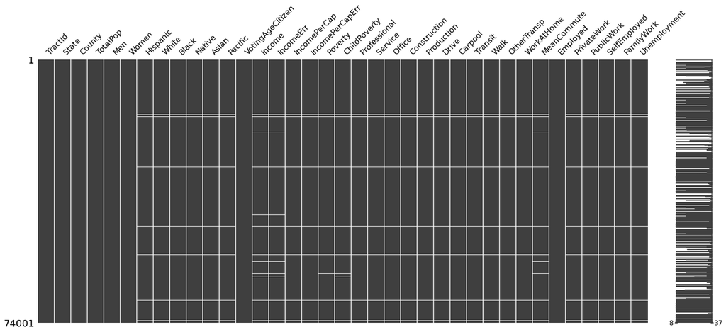

```python
# remove rows with missing data
import missingno as mn

mn.matrix(df)
plt.show()
```

```python
rows_with_nan = df[df.isnull().any(axis=1)]
num_rows_with_nan = len(rows_with_nan)
print('Number of rows: ', len(df))
print('Number of rows with NaN values: ', num_rows_with_nan)
print('Ratio of rows with NaN to all rows: ', num_rows_with_nan / len(df))
```

```
Number of rows:  74001
Number of rows with NaN values:  1283
Ratio of rows with NaN to all rows:  0.017337603545898028
```

```python
df = df.dropna()
print('New number of rows: ', len(df))
```

```
New number of rows:  72718
```

```python
# drop county
df_new = df.drop(columns=['TractId', 'County'])

# encode string data as integers
df_new['State'] = df_new['State'].astype('category').cat.codes
```

```python
# split dataset into 80/20 for train/test
from sklearn.model_selection import train_test_split

target_var_name = 'ChildPoverty'

X = df_new.loc[:, df_new.columns != target_var_name]
y = df_new.loc[:, df_new.columns == target_var_name][target_var_name]

X_train, X_test, y_train, y_test = train_test_split(X, y, test_size=0.2, random_state=42)
```

```python
# quantize child poverty variable (% of children under poverty level) into 4 categories

def quantize_child_poverty_rate(cpr):
    if cpr <= 3:
        return 0
    if cpr <= 11:
        return 1
    if cpr <= 22:
        return 2
    if cpr <= 100:
        return 3

y_train = y_train.apply(lambda x: quantize_child_poverty_rate(x))
y_test = y_test.apply(lambda x: quantize_child_poverty_rate(x))

# df_new.loc[:, df_new.columns == target_var_name][target_var_name].quantile([0.25,0.5,0.75])
```

```python
unique_elements, counts_elements = np.unique(list(y_train), return_counts=True)
print(unique_elements)
print(counts_elements)
```

```
[0 1 2 3]
[ 8792 13318 13266 22798]
```

We declared thresholds for our four different categories of child poverty rates by researching current goals and policies focused on reducing child poverty. There is a global goal to get child poverty rates down below 3%, so we chose that as our first threshold. The current average child poverty rate in the U.S. is 21.2%, which is far above the 3% goal. This led us to create our second threshold at half the current U.S. rate, and our third threshold as the current U.S. rate. Establishing these three thresholds gives us a relatively good quantization of our data into four different categories, but this results in unbalanced classes.

To balance the dataset, we conduct random oversampling of the minority classes only on the training data. Balancing the dataset should not be done for both the training and the testing set. Doing balancing on the testing set would be a form of data snooping - misrepresenting the reality of the actual data in the real world. We don't want to massage or disrupt the test data at all.

Our way of oversampling is known to increase the likelihood of overfitting - a better way would be synthetic minority oversampling technique (SMOTE), but this is a bit difficult to use since we have not encoded our categorical variables yet.

```python
# balance the dataset using random oversampling of the minority classes
# https://towardsdatascience.com/sampling-techniques-for-extremely-imbalanced-data-part-ii-over-sampling-d61b43bc4879

# sample SMOTE code
# from imblearn.over_sampling import SMOTE
# sm = SMOTE(random_state=12, sampling_strategy='not majority')
# X_train_res, y_train_res = sm.fit_sample(X_train, y_train)

# code adapted from https://www.kaggle.com/rafjaa/resampling-strategies-for-imbalanced-datasets
X_train_0 = X_train[y_train == 0]
X_train_1 = X_train[y_train == 1]
X_train_2 = X_train[y_train == 2]
X_train_3 = X_train[y_train == 3]

X_train_0_under = X_train_0.sample(len(X_train_3) - len(X_train_0), replace=True)
X_train_1_under = X_train_1.sample(len(X_train_3) - len(X_train_1), replace=True)
X_train_2_under = X_train_2.sample(len(X_train_3) - len(X_train_2), replace=True)

y_train_0_under = y_train[X_train_0_under.index]
y_train_1_under = y_train[X_train_1_under.index]
y_train_2_under = y_train[X_train_2_under.index]

X_train = pd.concat([X_train, X_train_0_under, X_train_1_under, X_train_2_under], axis=0)
y_train = pd.concat([y_train, y_train_0_under, y_train_1_under, y_train_2_under], axis=0)
```

```python
unique_elements, counts_elements = np.unique(list(y_train), return_counts=True)
print(unique_elements)
print(counts_elements)
```

```
[0 1 2 3]
[22798 22798 22798 22798]
```

## 2. Preprocessing

```python
y_train = y_train.to_numpy()
y_test = y_test.to_numpy()
```

```python
# Example adapted from https://github.com/rasbt/python-machine-learning-book/blob/master/code/ch12/ch12.ipynb
# Original Author: Sebastian Raschka

# This is the optional book we use in the course, excellent intuitions and straightforward programming examples
# please note, however, that this code has been manipulated to reflect our assumptions and notation.
import numpy as np
from scipy.special import expit
import pandas as pd
import sys

# start with a simple base classifier, which can't be fit or predicted
# it only has internal classes to be used by classes that will subclass it
class TwoLayerPerceptronBase(object):
    def __init__(self, n_hidden=30,
                 C=0.0, epochs=500, eta=0.001, random_state=None):
        np.random.seed(random_state)
        self.n_hidden = n_hidden
        self.l2_C = C
        self.epochs = epochs
        self.eta = eta

    @staticmethod
    def _encode_labels(y):
        """Encode labels into one-hot representation"""
        onehot = pd.get_dummies(y).values.T

        return onehot

    def _initialize_weights(self):
        """Initialize weights with small random numbers."""
        W1_num_elems = (self.n_features_ + 1)*self.n_hidden
        W1 = np.random.uniform(-1.0, 1.0,size=W1_num_elems)
        W1 = W1.reshape(self.n_hidden, self.n_features_ + 1) # reshape to be W

        W2_num_elems = (self.n_hidden + 1)*self.n_output_
        W2 = np.random.uniform(-1.0, 1.0, size=W2_num_elems)
        W2 = W2.reshape(self.n_output_, self.n_hidden + 1)
        return W1, W2

    @staticmethod
    def _sigmoid(z):
        """Use scipy.special.expit to avoid overflow"""
        # 1.0 / (1.0 + np.exp(-z))
        return expit(z)

    @staticmethod
    def _relu(Z):
        return np.maximum(0,Z.copy())

    @staticmethod
    def _add_bias_unit(X, how='column'):
        """Add bias unit (column or row of 1s) to array at index 0"""
        if how == 'column':
            ones = np.ones((X.shape[0], 1))
            X_new = np.hstack((ones, X))
        elif how == 'row':
            ones = np.ones((1, X.shape[1]))
            X_new = np.vstack((ones, X))
        return X_new

    @staticmethod
    def _L2_reg(lambda_, W1, W2):
        """Compute L2-regularization cost"""
        # only compute for non-bias terms
        return (lambda_/2.0) * np.sqrt(np.mean(W1[:, 1:] ** 2) + np.mean(W2[:, 1:] ** 2))

    def _cost(self,A3,Y_enc,W1,W2):
        '''Get the objective function value'''
        cost = np.mean((Y_enc-A3)**2)
        L2_term = self._L2_reg(self.l2_C, W1, W2)
        return cost + L2_term

    def _feedforward(self, X, W1, W2):
        """Compute feedforward step
        """
        A1 = self._add_bias_unit(X, how='column')
        A1 = A1.T
        Z1 = W1 @ A1
        A2 = self._sigmoid(Z1)
        A2 = self._add_bias_unit(A2, how='row')
        Z2 = W2 @ A2
        A3 = self._sigmoid(Z2)
        return A1, Z1, A2, Z2, A3

    def _get_gradient(self, A1, A2, A3, Z1, Z2, Y_enc, W1, W2):
        """ Compute gradient step using backpropagation.
        """
        # vectorized backpropagation
        V2 = -2*(Y_enc-A3)*A3*(1-A3)  # last layer sensitivity
        V1 = A2*(1-A2)*(W2.T @ V2) # back prop the sensitivity

        grad2 = V2 @ A2.T # no bias on final layer
        grad1 = V1[1:,:] @ A1.T # dont back prop sensitivity of bias


        # regularize weights that are not bias terms
        grad1[:, 1:] += W1[:, 1:] * self.l2_C
        grad2[:, 1:] += W2[:, 1:] * self.l2_C

        return grad1, grad2

    def predict(self, X):
        """Predict class labels"""
        _, _, _, _, A3 = self._feedforward(X, self.W1, self.W2)
        y_pred = np.argmax(A3, axis=0)
        return y_pred
```

```python
from sklearn.metrics import accuracy_score

# minibatching, cross entropy loss function, Glorot initialization, and ReLu layers
class TLP(TwoLayerPerceptronBase):
    def __init__(self, alpha=0.0, decrease_const=0.0, shuffle=True,
                 minibatches=1, **kwds):
        # need to add to the original initializer
        self.alpha = alpha
        self.decrease_const = decrease_const
        self.shuffle = shuffle
        self.minibatches = minibatches
        # but keep other keywords
        super().__init__(**kwds)

    def _initialize_weights(self):
        """Initialize weights with small random numbers."""
        # suggested relu/sigmoid bounds
        # Xavier Glorot, Yoshua Bengio ;
        #  Understanding the difficulty of training deep feedforward neural networks
        #  Conference on Artificial Intelligence and Statistics, PMLR 9:249-256, 2010.
        init_bound = np.sqrt(2)*np.sqrt(6. / (self.n_hidden + self.n_features_ + 1))
        W1 = np.random.uniform(-init_bound, init_bound,(self.n_hidden, self.n_features_ + 1))
        W1[:,:1] = 0

        # reduce the final layer magnitude in order to balance the size of the gradients
        # between
        init_bound = 4*np.sqrt(6 / (self.n_output_ + self.n_hidden + 1))
        W2 = np.random.uniform(-init_bound, init_bound,(self.n_output_, self.n_hidden + 1))
        W2[:,:1] = 0

        return W1, W2

    def _feedforward(self, X, W1, W2):
        """Compute feedforward step
        """
        # A1->W1->ReLu->A2->W2->Sigmoid
        A1 = self._add_bias_unit(X.T, how='row')
        Z1 = W1 @ A1
        A2 = self._relu(Z1)
        A2 = self._add_bias_unit(A2, how='row')
        Z2 = W2 @ A2
        A3 = self._sigmoid(Z2) # never use relu as last layer for classification (yuck!)
        return A1, Z1, A2, Z2, A3

    def fit(self, X, y, print_progress=False):
        """ Learn weights from training data. With mini-batch"""
        X_data, y_data = X.copy(), y.copy()
        Y_enc = self._encode_labels(y)

        # init weights and setup matrices
        self.n_features_ = X_data.shape[1]
        self.n_output_ = Y_enc.shape[0]
        self.W1, self.W2 = self._initialize_weights()

        delta_W1_prev = np.zeros(self.W1.shape)
        delta_W2_prev = np.zeros(self.W2.shape)

        self.cost_ = []
        self.score_ = []
        # get starting acc
        self.score_.append(accuracy_score(y_data,self.predict(X_data)))
        for i in range(self.epochs):

            # adaptive learning rate
            self.eta /= (1 + self.decrease_const*i)

            if print_progress>0 and (i+1)%print_progress==0:
                sys.stderr.write('\rEpoch: %d/%d' % (i+1, self.epochs))
                sys.stderr.flush()

            if self.shuffle:
                idx_shuffle = np.random.permutation(y_data.shape[0])
                X_data, Y_enc, y_data = X_data[idx_shuffle], Y_enc[:, idx_shuffle], y_data[idx_shuffle]

            mini = np.array_split(range(y_data.shape[0]), self.minibatches)
            mini_cost = []
            for idx in mini:

                # feedforward
                A1, Z1, A2, Z2, A3 = self._feedforward(X_data[idx],
                                                       self.W1,
                                                       self.W2)

                cost = self._cost(A3,Y_enc[:, idx],self.W1,self.W2)
                mini_cost.append(cost) # this appends cost of mini-batch only

                # compute gradient via backpropagation
                grad1, grad2 = self._get_gradient(A1=A1, A2=A2, A3=A3, Z1=Z1, Z2=Z2,
                                                  Y_enc=Y_enc[:, idx],
                                                  W1=self.W1,W2=self.W2)

                # momentum calculations
                delta_W1, delta_W2 = self.eta * grad1, self.eta * grad2
                self.W1 -= (delta_W1 + (self.alpha * delta_W1_prev))
                self.W2 -= (delta_W2 + (self.alpha * delta_W2_prev))
                delta_W1_prev, delta_W2_prev = delta_W1, delta_W2

            self.cost_.append(mini_cost)
            self.score_.append(accuracy_score(y_data,self.predict(X_data)))

        return self

    def _cost(self,A3,Y_enc,W1,W2):
        '''Get the objective function value'''
        cost = -np.mean(np.nan_to_num((Y_enc*np.log(A3)+(1-Y_enc)*np.log(1-A3))))
        L2_term = self._L2_reg(self.l2_C, W1, W2)
        return cost + L2_term

    def _get_gradient(self, A1, A2, A3, Z1, Z2, Y_enc, W1, W2):
        """ Compute gradient step using backpropagation.
        """
        # vectorized backpropagation
        V2 = (A3-Y_enc)

        # V3[Z2<=0] = 0 # could can change to be relu back prop on this layer too!

        # old update: V1 = A2*(1-A2)*(W2.T @ V2)
        # the derivative of sigmoid was A2(1-A2), but now that is relu
        # so we change it to:
        Z1_with_bias = self._add_bias_unit(Z1,how='row')
        V1 = (W2.T @ V2)
        V1[Z1_with_bias<=0] = 0
        # relu derivative only zeros out certain values! easy!

        grad2 = V2 @ A2.T
        grad1 = V1[1:,:] @ A1.T


        # regularize weights that are not bias terms
        grad1[:, 1:] += (W1[:, 1:] * self.l2_C)
        grad2[:, 1:] += (W2[:, 1:] * self.l2_C)

        return grad1, grad2
```

```python
params = dict(n_hidden=40,
              C=0.1, # tradeoff L2 regularizer
              epochs=200, # iterations
              eta=0.001,  # learning rate
              alpha=0.001,
              decrease_const=0.00001,
              minibatches=50,
              shuffle=True,
              random_state=1)
```

```python
%%time
nn = TLP(**params)
nn.fit(X_train.to_numpy(), y_train, print_progress=10)
yhat = nn.predict(X_test.to_numpy())
print('Test acc:', accuracy_score(y_test, yhat))
```

```
Test acc: 0.23336083608360836
CPU times: user 2min 20s, sys: 15.9 s, total: 2min 36s
Wall time: 39.9 s
```

```python
from sklearn.metrics import accuracy_score
import matplotlib.pyplot as plt
%matplotlib inline

plt.style.use('ggplot')

def loss_vs_epochs(nn, X_train, y_train, X_test, y_test, title="", color="red"):

    print("=================")
    print(title,":")
    yhat = nn.predict(X_train)
    print('Resubstitution acc:',accuracy_score(y_train,yhat))

    yhat = nn.predict(X_test)
    print('Validation acc:',accuracy_score(y_test,yhat))

    if hasattr(nn,'val_score_'):
        plt.plot(range(len(nn.val_score_)), nn.val_score_, color=color,label=title)
        plt.ylabel('Validation Accuracy')
    else:
        plt.plot(range(len(nn.score_)), nn.score_, color=color,label=title)
        plt.ylabel('Resub Accuracy')

    plt.xlabel('Epochs')
    plt.tight_layout()
    plt.legend(loc='best')
    plt.grid(True)
```

```
=================
TLP: No Norm, No Encoding :
Resubstitution acc: 0.25
Validation acc: 0.23336083608360836
```

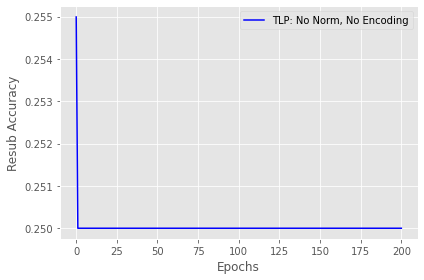

```python
loss_vs_epochs(nn, X_train, y_train, X_test, y_test, title="TLP: No Norm, No Encoding", color="blue")

plt.show()
```

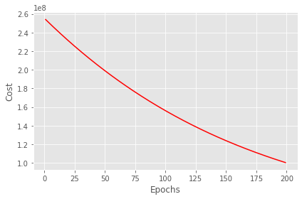

```python
# take the mean of each minibatch epoch
cost_avgs = [np.mean(x) for x in nn.cost_]

plt.plot(range(len(cost_avgs)), cost_avgs, color='red')
plt.ylabel('Cost')
plt.xlabel('Epochs')
plt.tight_layout()
plt.show()
```

### Normalization of continuous numeric feature data

```python
continuous_numeric_columns = [col for col in X_train.columns if col != 'State']
```

```python
# normalize continuous numeric feature data
from sklearn.preprocessing import StandardScaler

scaler = StandardScaler()

X_train_norm = X_train.copy()
X_test_norm = X_test.copy()
X_train_norm[continuous_numeric_columns] = scaler.fit_transform(X_train[continuous_numeric_columns])
X_test_norm[continuous_numeric_columns] = scaler.fit_transform(X_test[continuous_numeric_columns])

# .values.reshape(-1, 1)
```

```python
%%time
nn_norm = TLP(**params)
nn_norm.fit(X_train_norm.to_numpy(), y_train, print_progress=1)
yhat_norm = nn_norm.predict(X_test_norm.to_numpy())
print('Test acc:', accuracy_score(y_test, yhat_norm))
```

```
Epoch: 1/200<ipython-input-14-775f39119f4b>:105: RuntimeWarning: divide by zero encountered in log
  cost = -np.mean(np.nan_to_num((Y_enc*np.log(A3)+(1-Y_enc)*np.log(1-A3))))
Epoch: 200/200
```

```
Test acc: 0.24085533553355334
CPU times: user 2min 18s, sys: 15.4 s, total: 2min 34s
Wall time: 38.8 s
```

```
=================
TLP: Norm, No Encoding :
Resubstitution acc: 0.2591345732081762
Validation acc: 0.24085533553355334
```

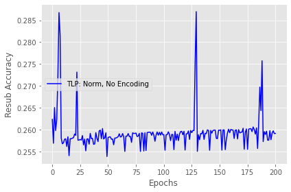

```python
loss_vs_epochs(nn_norm, X_train_norm, y_train, X_test_norm, y_test, title="TLP: Norm, No Encoding", color="blue")

plt.show()
```

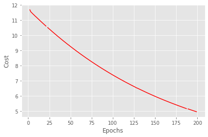

```python
# take the mean of each minibatch epoch
cost_avgs = [np.mean(x) for x in nn_norm.cost_]

plt.plot(range(len(cost_avgs)), cost_avgs, color='red')
plt.ylabel('Cost')
plt.xlabel('Epochs')
plt.tight_layout()
plt.show()
```

### Normalize and one hot encode the categorical data

```python
# one hot encode the categorical data (the state variable)
ohe_state = pd.get_dummies(df.State, prefix='State')
```

```python
X_train_norm_encode = pd.concat([X_train_norm, ohe_state.loc[X_train_norm.index]], axis=1, sort=False)
X_train_norm_encode = X_train_norm_encode.drop(columns=['State'])

X_test_norm_encode = pd.concat([X_test_norm, ohe_state.loc[X_test_norm.index]], axis=1, sort=False)
X_test_norm_encode = X_test_norm_encode.drop(columns=['State'])
```

```python
%%time
nn_norm_encode = TLP(**params)
nn_norm_encode.fit(X_train_norm_encode.to_numpy(), y_train, print_progress=10)
yhat_norm_encode = nn_norm_encode.predict(X_test_norm_encode.to_numpy())
print('Test acc:', accuracy_score(y_test, yhat_norm_encode))
```

```
Test acc: 0.5966721672167217
CPU times: user 3min 10s, sys: 18.4 s, total: 3min 29s
Wall time: 52.8 s
```

```
=================
TLP: Norm, Encode :
Resubstitution acc: 0.7233309939468374
Validation acc: 0.5966721672167217
```

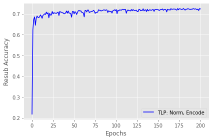

```python
loss_vs_epochs(nn_norm_encode, X_train_norm_encode, y_train, X_test_norm_encode, y_test,
               title="TLP: Norm, Encode", color="blue")

plt.show()
```

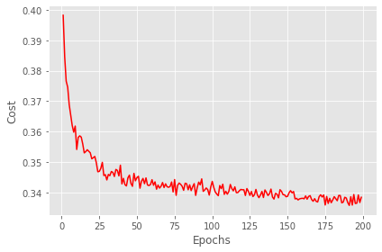

```python
# take the mean of each minibatch epoch
cost_avgs = [np.mean(x) for x in nn_norm_encode.cost_]

plt.plot(range(len(cost_avgs)), cost_avgs, color='red')
plt.ylabel('Cost')
plt.xlabel('Epochs')
plt.tight_layout()
plt.show()
```

### Compare models using McNemar's test

McNemar's test is a statistical signifiance test that can be used to compare the performance of different machine learning models. The test is "recommended in those cases where the algorithms being compared can only be evaluated once" [[ref](https://machinelearningmastery.com/mcnemars-test-for-machine-learning/)].

The McNemar test demonstrates that all of the models' performances (and therefore the models themselves) are significantly different from one another. All three McNemar tests (between the 1st and 2nd classifier, between the 2nd and 3rd classifer, and between the 1st and 3rd classifer) result in the p-value being below alpha of 0.05, which means that we reject the null hypothesis and that there is a statistically significant difference in the disagreement between each pair of models.

```python
def calculate_contingency_table(cl1_array, cl2_array):
    table = np.zeros((2, 2))
    for r1, r2 in zip(cl1_array, cl2_array):
        if r1 and r2:
            table[0][0] += 1
        elif r1 and not r2:
            table[0][1] += 1
        elif not r1 and r2:
            table[1][0] += 1
        else:
            table[1][1] += 1

    return table
```

```python
cl1_correct = y_test == yhat
cl2_correct = y_test == yhat_norm
cl3_correct = y_test == yhat_norm_encode

cl1_cl2_ct = calculate_contingency_table(cl1_correct, cl2_correct)
cl1_cl3_ct = calculate_contingency_table(cl1_correct, cl3_correct)
cl2_cl3_ct = calculate_contingency_table(cl2_correct, cl3_correct)
```

```python
from statsmodels.stats.contingency_tables import mcnemar
alpha = 0.05

# code adapted from https://machinelearningmastery.com/mcnemars-test-for-machine-learning/
def mcnemar_test(table):
    # calculate mcnemar test from contingency table and print out statistical results
    result = mcnemar(table, exact=True)
    print('statistic=%.3f, p-value=%.3f' % (result.statistic, result.pvalue))

    # interpret the p-value
    if result.pvalue > alpha:
        print('Same proportions of errors (fail to reject H0)')
    else:
        print('Different proportions of errors (reject H0)')
```

```python
print("Classifier 1 (C1): No Norm, No Encode")
print("Classifier 2 (C2): Norm, No Encode")
print("Classifier 3 (C3): Norm, Encode")
print()

print("C1 and C2:")
mcnemar_test(cl1_cl2_ct)
print()

print("C1 and C3:")
mcnemar_test(cl1_cl3_ct)
print()

print("C2 and C3:")
mcnemar_test(cl2_cl3_ct)
print()
```

```
Classifier 1 (C1): No Norm, No Encode
Classifier 2 (C2): Norm, No Encode
Classifier 3 (C3): Norm, Encode

C1 and C2:
statistic=22.000, p-value=0.000
Different proportions of errors (reject H0)

C1 and C3:
statistic=2102.000, p-value=0.000
Different proportions of errors (reject H0)

C2 and C3:
statistic=2103.000, p-value=0.000
Different proportions of errors (reject H0)
```

## 3. Modeling

```python
class CustomMLPBase(object):
    def __init__(self, n_hidden=30,
                 C=0.0, epochs=500, eta=0.001, random_state=None, layers=3):
        np.random.seed(random_state)
        self.n_hidden = n_hidden
        self.l2_C = C
        self.epochs = epochs
        self.eta = eta
        self.layers=layers

    @staticmethod
    def _encode_labels(y):
        """Encode labels into one-hot representation"""
        onehot = pd.get_dummies(y).values.T

        return onehot

    def _initialize_weights(self):
        """Initialize weights with small random numbers."""
        initWeights=[]
        W1_num_elems = (self.n_features_ + 1)*self.n_hidden
        W1 = np.random.uniform(-1.0, 1.0, size=W1_num_elems)
        W1 = W1.reshape(self.n_hidden, self.n_features_ + 1) # reshape to be W1
        initWeights.append(W1)
        for x in range(0,self.layers-2):
            W1_num_elems = (initWeights[x].shape[0]+1 )*(self.n_hidden)
            W1 = np.random.uniform(-1.0, 1.0, size=W1_num_elems)
            W1 = W1.reshape(self.n_hidden ,initWeights[x].shape[0]+1) # reshape to be W2
            initWeights.append(W1)

        W2_num_elems = (initWeights[self.layers-2].shape[0] + 1 )*self.n_output_
        W2 = np.random.uniform(-1.0, 1.0, size=W2_num_elems)
        W2 = W2.reshape(self.n_output_,(initWeights[self.layers-2].shape[0] + 1))
        initWeights.append(W2)
        return initWeights

    @staticmethod
    def _sigmoid(z):
        """Use scipy.special.expit to avoid overflow"""
        # 1.0 / (1.0 + np.exp(-z))
        return expit(z)

    @staticmethod
    def _add_bias_unit(X, how='column'):
        """Add bias unit (column or row of 1s) to array at index 0"""
        if how == 'column':
            ones = np.ones((X.shape[0], 1))
            X_new = np.hstack((ones, X))
        elif how == 'row':
            ones = np.ones((1, X.shape[1]))
            X_new = np.vstack((ones, X))
        return X_new

    @staticmethod
    def _L2_reg(lambda_, weights):
        """Compute L2-regularization cost"""
        # only compute for non-bias terms
        counter=0
        for x in range(0,len(weights)):
            counter+=np.mean(weights[x][:, 1:] ** 2)
        return (lambda_/2.0) * np.sqrt(counter)

    def _cost(self,A3,Y_enc,weights):
        '''Get the objective function value'''
        cost = np.mean((Y_enc-A3)**2)
        L2_term = self._L2_reg(self.l2_C, weights)
        return cost + L2_term
```

```python
from sklearn.metrics import accuracy_score

class CustomMLP(CustomMLPBase):
    def __init__(self, alpha=0.0, decrease_const=0.0, **kwds):
        # need to add to the original initializer
        self.alpha = alpha
        self.decrease_const = decrease_const
        # but keep other keywords
        super().__init__(**kwds)

    def _feedforward(self, X, W):
        """Compute feedforward step
        -----------
        X : Input layer with original features.
        W1: Weight matrix for input layer -> hidden layer.
        W2: Weight matrix for hidden layer -> output layer.
        ----------
        a1-a3 : activations into layer (or output layer)
        z1-z2 : layer inputs
        """

        currA = self._add_bias_unit(X.T, how='row')
        currZ = W[0] @ currA
        currNextA = self._sigmoid(currZ)

        infoReturn =[]
        infoReturn.append(currA)
        infoReturn.append(currZ)
        for x in range(1,len(W)):
            currA = self._add_bias_unit(currNextA, how='row')
            currZ = W[x] @ currA
            currNextA = self._sigmoid(currZ)
            infoReturn.append(currA)
            infoReturn.append(currZ)
        infoReturn.append(currNextA)
        return infoReturn


    def _get_gradient(self, dataStore, Y_enc, dataW):
        """ Compute gradient step using backpropagation.
        """
        alist=[]
        for x in range(0,len(dataStore)):
            if x%2==0:
                alist.append(dataStore[x])
        gradArr=[]
        for x in range(0,len(dataW)):
            gradArr.append(np.zeros(dataW[x].shape))
        aCounter = len(alist)-1
        gradCounter= len(gradArr)-1
        V2 = -2*(Y_enc-alist[aCounter])*alist[aCounter]*(1-alist[aCounter])
        gradArr[gradCounter] = V2 @ alist[aCounter-1].T
        aCounter -=1
        gradCounter -=1
        wCounter = len(dataW)-1
        vCurrent = V2
        runnercount=0
        for x in range(0,self.layers-1):
            vTemp = (alist[aCounter])*(1-(alist[aCounter]))
            vTemp = vTemp*((dataW[wCounter].T) @ vCurrent)
            gradArr[gradCounter] = vTemp[1:,:]@alist[aCounter-1].T
            aCounter-=1
            gradCounter-=1
            wCounter-=1
            vCurrent=vTemp[1:,:]
            runnercount+=1
        for x in range(0,len(dataW)):
            gradArr[x][:,1:]+=dataW[x][:,1:]*self.l2_C
        return gradArr


    def predict(self, X):
        """Predict class labels"""
        dataRet = self._feedforward(X, self.weights)
        y_pred = np.argmax(dataRet[len(dataRet)-1], axis=0)
        return y_pred


    def fit(self, X, y, print_progress=False):
        """ Learn weights from training data."""
        X_data, y_data = X.copy(), y.copy()
        Y_enc = self._encode_labels(y)

        self.n_features_ = X_data.shape[1]
        self.n_output_ = Y_enc.shape[0]
        self.weights=self._initialize_weights()

        delta_W1_prev = np.zeros(self.weights[0].shape)
        delta_W2_prev = np.zeros(self.weights[1].shape)

        self.cost_ = []
        self.weightHold=[]


        for x in range(0,len(self.weights)):
            self.weightHold.append([])
        for i in range(self.epochs):
            self.eta /= (1 + self.decrease_const*x)

            if print_progress>0 and (i+1)%print_progress==0:
                sys.stderr.write('\rEpoch: %d/%d' % (i+1, self.epochs))
                sys.stderr.flush()

            dataRet = self._feedforward(X_data,self.weights)
            cost = self._cost(dataRet[len(dataRet)-1],Y_enc,self.weights)
            self.cost_.append(cost)
            gradArr = self._get_gradient(dataStore =dataRet, Y_enc=Y_enc,
                                              dataW=self.weights)

            weightCount=0
            for x in range(0,len(gradArr)):
                self.weights[x]-=self.eta*gradArr[x]
                self.weightHold[x].append(gradArr[x].mean())

                if self.alpha > 0:
                    grad1 = gradArr[0]
                    grad2 = gradArr[1]

                    delta_W1, delta_W2 = self.eta * grad1, self.eta * grad2
                    self.weights[0] -= (delta_W1 + (self.alpha * delta_W1_prev))

                    self.weights[1] -= (delta_W2 + (self.alpha * delta_W2_prev))
                    delta_W1_prev, delta_W2_prev = delta_W1, delta_W2
                self.weightHold.append(accuracy_score(y_data,self.predict(X_data)))

        return self
```

```python
params = dict(n_hidden=50,
              C=0.1, # tradeoff L2 regularizer
              epochs=200, # iterations
              eta=0.001,  # learning rate
              random_state=1,
              layers=2)
```

```python
%%time
nn = CustomMLP(**params)
nn.fit(X_train_norm_encode.to_numpy(), y_train, print_progress=10)
yhat = nn.predict(X_test_norm_encode.to_numpy())
print('Test acc:', accuracy_score(y_test,yhat))
```

```
Epoch: 200/200
```

```
Test acc: 0.5113448844884488
CPU times: user 3min 52s, sys: 8.8 s, total: 4min 1s
Wall time: 1min
```